# Defending The Go-Gos: Predicting Slot Receiver Routes

### By Kevin Baer, UCLA Second Year Undergraduate

## Introduction

*“We Got The Beat”* (1981), The Go-Go’s most famous song, is an apt title for what this paper intends to accomplish. But who are The Go-Go’s and what does “the beat” mean?

The following chart provides the motivation for this paper’s topic.

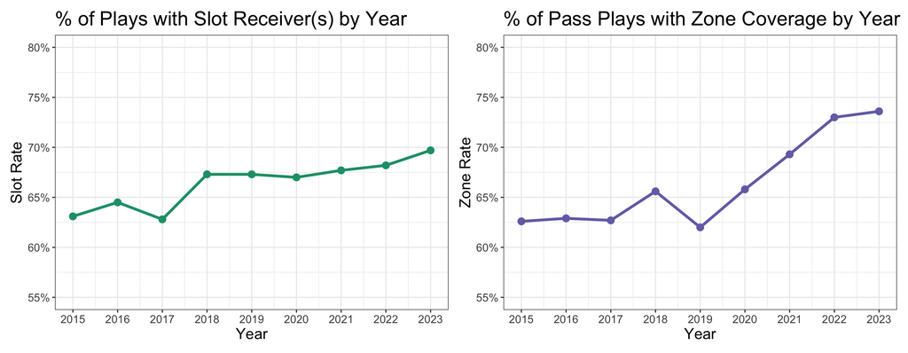

Over the past decade, offenses have used more formations with slot receivers and defenses have increased their zone coverage usage in a very similar manner. These are not the only two trends in the league, of course, but certainly large ones and likely at least somewhat related. Given that offense is largely proactive and defense is largely reactive, as well as some understanding of football scheme, it is reasonable to assume that the increase in zone coverage is, in part, because of the increase in slot receiver usage. But why and what can defenses do about it?

Why have defenses been playing less man? One reason is that defending slot receivers in man coverage is hard. Slot receivers are often off the line of scrimmage, so they can’t be pressed. But more importantly, they often have a “two-way go”, option, or choice route, terms I’ll use somewhat interchangeably to refer to routes where the receiver can choose which direction to go based on the defense. Against man, these routes become one-cut linear runaways based on the leverage of the CB, while against zone they’ll sit down in a hole.

Playing man coverage in the NFL on outside receivers is difficult enough even though you have the sideline and the longer throws to get the ball there. **To get *“The Beat”* on the Go-Gos, I used pre-snap indicators to predict the routes run by slot receivers against man coverage.**

## **Defining the Scope**

Data preparation is more important than any predictive algorithm. Here’s what data made the cut.

All plays used were:

1. between Week 1 and 9 of the 2022 NFL season (the full length of the given dataset)
2. dropbacks
3. man coverage
4. not screen passes, trick plays, nor spikes[^1]

To determine which players classified as slot receivers, given we did not receive stance information nor is that easily calculable with this dataset, I used the following criteria.

Slot receivers must be:

1. on offense
2. in between the left and right most offensive players
3. running a route
4. outside of 5 yards linearly from the football[^2]

## Classifying Routes

[^1]: As always, a shoutout to FTN and nflverse for their free play-level data.
[^2]: (this cut out basically all TEs and RBs)